# Activity Monitoring Course Project

Henri Kynsilehto

9/21/2020

## Notice

As it can be expected that the readership of this document is well informed about the purpose and the scope of the document we will pass introductions and proceed to the bread and butter of the assignment.

## Prepare, read, and summarize data

```r
if(! file.exists('activity.csv')) {
    unzip('activity.zip')
}
data <- read.csv('activity.csv', header = TRUE)
summary(data)
```

```
##      steps            date              interval
##  Min.   :  0.00   Length:17568       Min.   :   0.0
##  1st Qu.:  0.00   Class :character   1st Qu.: 588.8
##  Median :  0.00   Mode  :character   Median :1177.5
##  Mean   : 37.38                      Mean   :1177.5
##  3rd Qu.: 12.00                      3rd Qu.:1766.2
##  Max.   :806.00                      Max.   :2355.0
##  NA's   :2304
```

## Transform date column

Apparently the date column’s data type chr and therefore we need to transform it to date format.

```r
data$date <- as.Date(data$date, "%Y-%m-%d")
str(data)
```

```
## 'data.frame':    17568 obs. of  3 variables:
##  $ steps   : int  NA NA NA NA NA NA NA NA NA NA ...
##  $ date    : Date, format: "2012-10-01" "2012-10-01" ...
##  $ interval: int  0 5 10 15 20 25 30 35 40 45 ...
```

## Mean total number of steps taken per day

We will next calculate total steps per day and plot histogram of daily totals and report the mean and the median of daily totals.

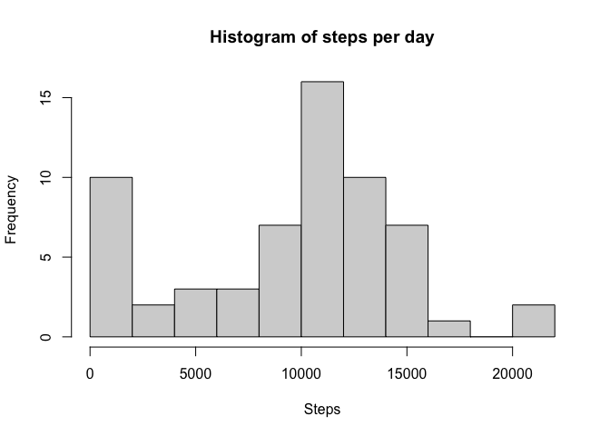

```r
dailyTotals <- aggregate(data$steps, by = list(data$date), FUN = sum,
                         na.rm = TRUE)
names(dailyTotals) <- c("Date", "Steps")
with(dailyTotals, hist(Steps, breaks = 10, main = "Histogram of steps per day"))
```

```r
mean(dailyTotals$Steps)
```

```
## [1] 9354.23
```

```r
median(dailyTotals$Steps)
```

```
## [1] 10395
```

## The average daily activity pattern

The subject seem to start his/her activities quite early, at around 5/6 AM. The active period ends at around 8 PM.

The average daily activity peak happens at around 9 AM. There is no similar peak during the afternoon and therefore one might guess that the morning peak is rather physical exercise than walking to work/school.

The peak activity interval is 8:35.

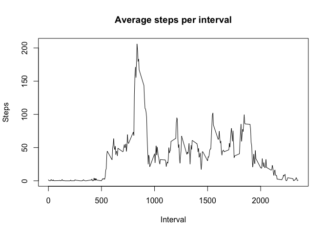

```r
intervalAverages <- aggregate(data$steps, by = list(data$interval),
                              FUN = mean, na.rm = TRUE )
names(intervalAverages) <- c("Interval", "Steps")
with(intervalAverages, plot(Interval, Steps, type = "l", main = "Average steps per interval"))
```

```r
intervalAverages[which.max(intervalAverages$Steps),]
```

```
##     Interval    Steps
## 104      835 206.1698
```

## Missing values

Looking at the summary of our data, we noticed that there are 2304 NA’s in the Steps column. We decided to impute NAs with interval averages and redo the histogram and mean values.

After imputing the NAs we noticed that while the left skewness remains the fake zero values from NAs is distributed along the x-axis. The mean and median are now exactly same.

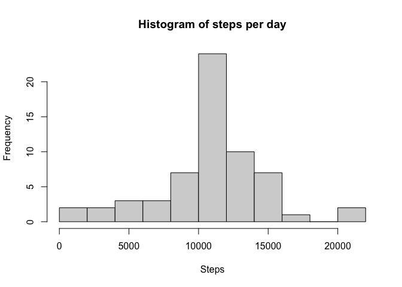

```r
newData <- data
newData$steps <- ifelse(is.na(newData$steps), intervalAverages[which(intervalAverages$Interval == intervalAverages),]$Steps, newData$steps)
dailyTotals <- aggregate(newData$steps, by = list(newData$date), FUN = sum,
                         na.rm = TRUE)
names(dailyTotals) <- c("Date", "Steps")
with(dailyTotals, hist(Steps, breaks = 10, main = "Histogram of steps per day"))
```

```r
mean(dailyTotals$Steps)
```

```
## [1] 10766.19
```

```r
median(dailyTotals$Steps)
```

```
## [1] 10766.19
```

## Differences in activity patterns between weekdays and weekends

Furthermore we wanted to compare activity patterns between weekdays and weekends.

Below we split the the data on weekday/weekend, average the interval steps over this grouping, and plot the timeline of steps.

The resulting plot reveals a more relaxed weekend pattern. While activity during the week starts quite sharp right after 5 AM, in weekend mornings the activity level rises more gently, reaching typical daytime activity level at around 7 AM. Also, the weekend activity from 8 to 9:30 is closer to activity level throughout the day; perhaps, if our guess about physical exercise is correct, then the subject does not exercise weekend mornings. As our final observation we note that during weekend nights, the level of activity stays higher until at around 10 PM.

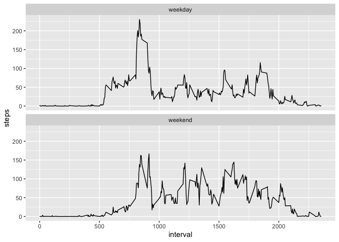

```r
newData$day <- ifelse(weekdays(newData$date) == "Saturday" | weekdays(newData$date) == "Sunday", "weekend", "weekday")
newData$day <- as.factor(newData$day)
intervalAverages <- aggregate(newData$steps, by = list(newData$interval, newData$day), FUN = mean)
names(intervalAverages) <- c("interval", "day", "steps")
library(ggplot2)
ggplot(data = intervalAverages, aes(interval, steps)) + geom_line() + facet_wrap(~ day, dir = 'v')
```